# s7_en

Research Seminar

Week 9: Seminar [November 9]

Sergi Martínez

smsoler@clio.uc3m.es | Office hours: Tuesdays 10:00–13:00 (by email)

## Today

- November 9:
  - Empirical design: quantitative section
  - Understanding and criticizing a paper: Rehm et al.
  - Ethics committee: 5 min meeting with each group
  - Group 7 presenting “Bolet, D. (2021). Drinking alone: local socio-cultural degradation and radical right support. Comparative Political Studies, 54(9), 1653–1692.”

**Regression (to last class–sorry)**

[figure not shown]

## Interactions: Estimating the difference between slopes

|  | **D is a dummy** | **Z is continuous** |
| --- | --- | --- |
| **Model** | $Y = \beta_0 + \beta_1 X + \beta_2 D + \beta_3 (X \times D) + \varepsilon$ | $Y = \beta_0 + \beta_1 X + \beta_2 Z + \beta_3 (X \times Z) + \varepsilon$ |
| **Example** | $Y = \beta_0 + \beta_1 GDP + \beta_2 Gender + \beta_3 (GDP \times Gender) + \varepsilon$ | $Y = \beta_0 + \beta_1 ethfrac + \beta_2 polity + \beta_3 (ethfrac \times polity) + \varepsilon$ |
| **Slope of X** | Two slopes: $\beta_1$ if D = 0, and $\beta_1 + \beta_3$ if D = 1 | One slope for each value of Z: $\dfrac{\partial Y}{\partial X} = \beta_1 + \beta_3 Z$ |
| **Intercept** | $\beta_0$ if D = 0, and $\beta_0 + \beta_2$ if D = 1 | $\beta_0 + \beta_2 Z$ |
| **$\beta_3$** | **Difference between the slopes** of the two groups. If $\beta_3 = 0$ the lines are parallel and there is no interaction | How much the effect of X changes for each **additional unit of Z**. Its sign tells us whether the effect grows or shrinks with Z |
| **$\beta_1$** | Effect of X **when D = 0** (not “the effect of X”) | Effect of X **when Z = 0**. It only makes sense if Z = 0 is a real value (otherwise, center Z) |
| **$\beta_2$** | Difference in level between groups **when X = 0** | Effect of Z **when X = 0** |
| **Effect to report** | $\beta_1$ for D = 0 and $\beta_1 + \beta_3$ for D = 1, with a standard error that includes the covariance between both coefficients | The effect of X **at specific values of Z** (minimum, mean, maximum, or ±1 SD of Z), with its confidence interval |
| **In R** | `lm(y ~ x * d)` is the same as `lm(y ~ x + d + x:d)` | `lm(y ~ x * z)` is the same as `lm(y ~ x + z + x:z)` |

In both cases no coefficient on its own tells the whole story, so we have to read the effect of X in each group (dummy) or at different values of Z (continuous)

## Example with Chinese FDI

[interactive chart not shown]

**Kitschelt and Rehm**

## Kitschelt and Rehm (2014)

[interactive chart not shown]

## Kitschelt and Rehm (2014) (II)

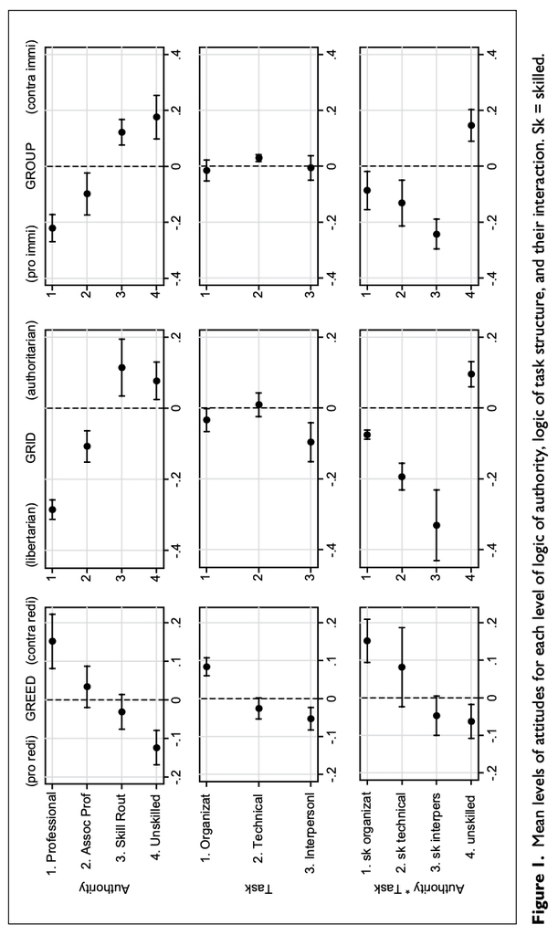

[figure not shown]

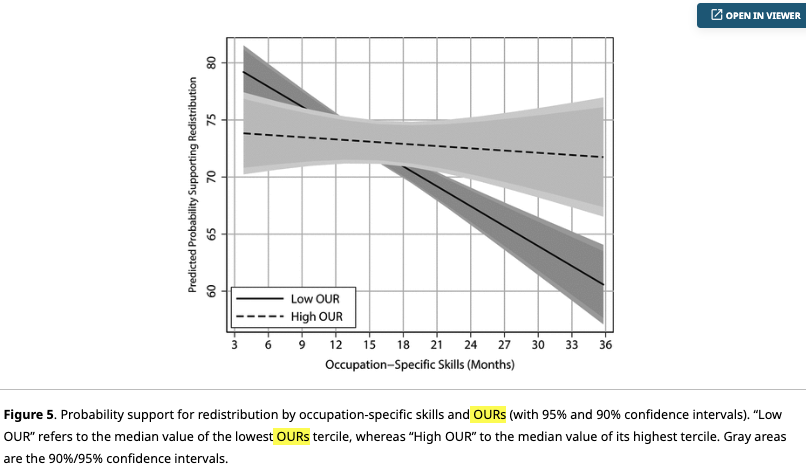

## How would you extend this discussion?

How would I do that?

1. Go to scholar.google.com, search for the paper, and click on “Cited by” to see who has cited it
2. Filter by year, check those published in the last 2 years to identify the research frontier
3. Find the most cited (weighted by the time after publication), identify the good journals, read the title, the abstract.
4. Read three-four of them the following way:
- Read the abstract to identify the question
- Scheme the theory section and the hypotheses
- Identify the data, the IV, the DVs (and now the mediators or interactive variables)
- Identify the main plot and spend 1 minute trying to understand it.
5. Be ready to explain it to the class in 3 minutes.

## Let’s go

**G1**: [Cohen and Pardos-Prado](https://www.dropbox.com/scl/fi/5ug729xndwf3bglinsk1o/PardosPradoetal-2024-regional_labor_markets_residential_mobility_and_antiimmigration_sentiment.pdf?rlkey=dkvcq7ircidm1krixg61l5t21&st=vp6dr2d9&dl=0)

**G2**: [Staalduinen and Zollinger](https://www.dropbox.com/scl/fi/i5jmhogd8ui3f2yzvjv8r/van-staalduinen-zollinger-2024-perceptions-of-social-mobility-gender-and-progressive-politics.pdf?rlkey=zlof9onsgwvl1gi5izy92d8ox&st=h52ulqx3&dl=0)

**G3**: [Weißenfels and Azzollini](https://www.dropbox.com/scl/fi/va8mt764f0wd3lkceeykw/wei-enfels-azzollini-2026-class-of-origin-and-voting-the-activating-role-of-volunteering-during-youth.pdf?rlkey=ok942ypczybf0ylizk0xboo6e&st=839uy8af&dl=0)

**What to do**:

- Read the abstract to identify the question
- Scheme the theory section and the hypotheses
- Identify the data, the IV, the DVs (and now the mediators or interactive variables)
- Identify the main plot (highlighted in yellow) and spend 1 minute trying to understand it.
- Explain it to the class in 3 minutes

`10:00`

## Now it’s time for the Ethics committee!

## Now it’s time for Group 7’s presentation!

## See you on Friday! Any question at smsoler@clio.uc3m.es

Research Seminar